# Health Sector Performance Charts

Martin HABIMANA

2025-01-06

Figure 1: Trend in child routine immunization coverages, FY 2019/20 to FY 2023/24

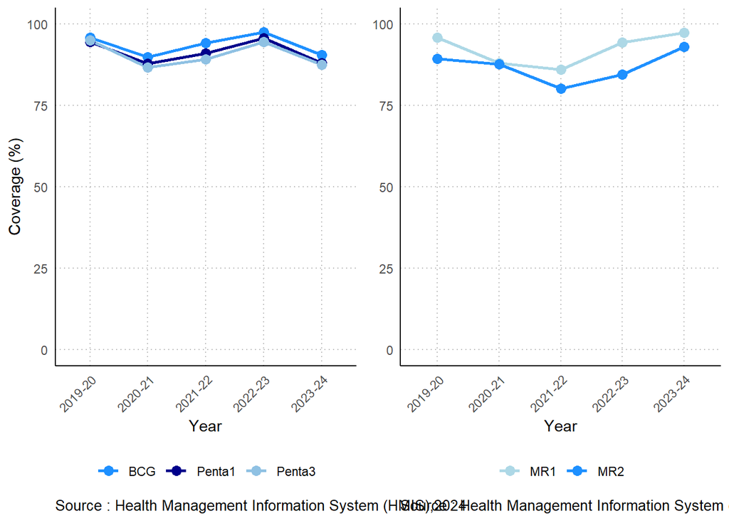

```r
library(ggplot2)
library(gridExtra)
library(reshape2)
library(ggrepel)

# Create a data frame
data <- data.frame(
  Year = c("2019-20", "2020-21", "2021-22", "2022-23", "2023-24"),
  BCG = c(95.90, 89.80, 94.20, 97.60, 90.50),
  Penta1 = c(94.50, 87.80, 91.10, 95.70, 88.00),
  Penta3 = c(95.10, 86.70, 89.20, 94.50, 87.60),
  MR1 = c(95.9, 88.1, 86.1, 94.3, 97.4),
  MR2 = c(89.40, 87.70, 80.20, 84.60, 93.10)
)

# Melt the data into long format
data_long <- melt(data, id.vars = "Year", variable.name = "Indicator", value.name = "Coverage")

# Define custom colors
custom_colors <- c("#1E90FF", "#00008B", "#8FC1E3", "lightblue", "#1E90FF")

# Plot 1: For BCG, Penta1, and Penta3
plot1 <- ggplot(data_long[data_long$Indicator %in% c("BCG", "Penta1", "Penta3"), ],
                aes(x = Year, y = Coverage, color = Indicator, group = Indicator)) +
  geom_line(size = 1) +
  geom_point(size = 3) +
  scale_color_manual(values = custom_colors[1:3]) +
  scale_y_continuous(limits = c(0, 100), breaks = seq(0, 100, by = 25)) +
  theme_minimal(base_family = "sans") +
  labs(y = "Coverage (%)", x = "Year", color = NULL,caption = "Source : Health Management Information System (HMIS),2024") +  # Removed "Indicator" from legend
  theme(
    axis.text.x = element_text(angle = 45, hjust = 1),
    axis.line = element_line(color = "black", size = 0.5),  # Add x and y axis lines
    legend.position = "bottom",
    panel.grid.major = element_line(color = "gray", size = 0.5, linetype = "dotted"),
    panel.grid.minor = element_blank(),
    plot.caption = element_text(
      family = "sans", size = 10, hjust = 0
    )
  )
# Plot 2: For MR1 and MR2
plot2 <- ggplot(data_long[data_long$Indicator %in% c("MR1", "MR2"), ],
                aes(x = Year, y = Coverage, color = Indicator, group = Indicator)) +
  geom_line(size = 1) +
  geom_point(size = 3) +
  scale_color_manual(values = custom_colors[4:5]) +
  scale_y_continuous(limits = c(0, 100), breaks = seq(0, 100, by = 25)) +
  theme_minimal(base_family = "sans") +
  labs(y = NULL, x = "Year", color = NULL,caption = "Source : Health Management Information System (HMIS),2024") +  # Removed "Indicator" from legend
  theme(
    axis.text.x = element_text(angle = 45, hjust = 1),
    axis.line = element_line(color = "black", size = 0.5),  # Add x and y axis lines
    legend.position = "bottom",
    panel.grid.major = element_line(color = "gray", size = 0.5, linetype = "dotted"),
    panel.grid.minor = element_blank(),
    plot.caption = element_text(
      family = "sans", size = 10, hjust = 0
    )
  )

# Combine plots side by side
grid.arrange(plot1, plot2, ncol = 2)
```

Figure 2: Under 5 children treated for pneumonia, diarrhea and malaria, FY 2019/20 – 2023/24

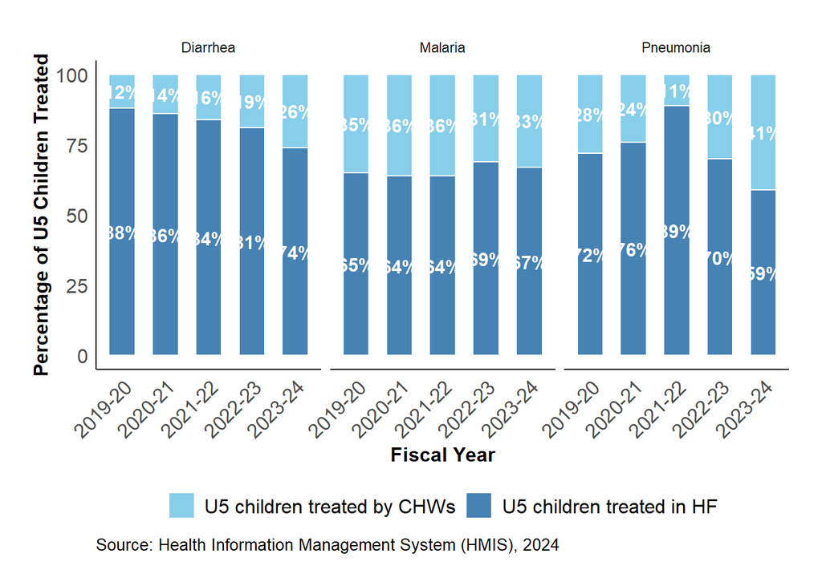

```r
# Load necessary libraries
library(ggplot2)
library(dplyr)
library(tidyr)
library(showtext)
# Set font families
title_font <- "sans"
body_font <- "sans"

# Data preparation
data <- data.frame(
  Year = c("2019-20", "2020-21", "2021-22", "2022-23", "2023-24"),
  Pneumonia_HF = c(72, 76, 89, 70, 59),        # U5 children treated in HF for pneumonia
  Pneumonia_CHWs = c(28, 24, 11, 30, 41),     # U5 children treated by CHWs for pneumonia
  Diarrhea_HF = c(88, 86, 84, 81, 74),        # U5 children treated in HF for diarrhea
  Diarrhea_CHWs = c(12, 14, 16, 19, 26),      # U5 children treated by CHWs for diarrhea
  Malaria_HF = c(65, 64, 64, 69, 67),         # U5 children treated in HF for malaria
  Malaria_CHWs = c(35, 36, 36, 31, 33)        # U5 children treated by CHWs for malaria
)

# Reshape data for plotting
bar_data <- data %>%
  pivot_longer(cols = -Year, names_to = "Category", values_to = "Rate") %>%
  separate(Category, into = c("Condition", "Treatment"), sep = "_") %>%
  mutate(Treatment = ifelse(Treatment == "HF", "U5 children treated in HF", "U5 children treated by CHWs"))

# Ensure 'Year' is treated as an ordered factor with correct formatting
bar_data$Year <- factor(bar_data$Year, levels = c("2019-20", "2020-21", "2021-22", "2022-23", "2023-24"))

# Define plot texts as per SOP
caption_text <- "Source: Health Information Management System (HMIS), 2024"

# Plot
p <- ggplot(bar_data, aes(x = Year, y = Rate, fill = Treatment)) +
  # Stacked bar plot for each condition across years
  geom_bar(stat = "identity", position = "stack", color = "white", width = 0.6) +

  # Data labels
  geom_text(
    aes(label = paste0(round(Rate, 1), "%")),
    position = position_stack(vjust = 0.5),
    size = 4,
    family = body_font,
    fontface = "bold",
    color = "white"
  ) +

  # Scale for coloring
  scale_fill_manual(
    values = c(
      "U5 children treated in HF" = "#4682B4",       # Steel Blue
      "U5 children treated by CHWs" = "#87CEEB"      # Sky Blue
    )
  ) +

  # Labels and theme
  labs(
    caption = caption_text,
    x = "Fiscal Year",
    y = "Percentage of U5 Children Treated",
    fill = NULL
  ) +

  facet_wrap(~Condition, scales = "fixed", ncol = 3) +

  # Apply themes to match the SOP, with only x and y-axis lines
  theme_minimal(base_family = body_font) +
  theme(
    # Title and subtitle
    plot.title = element_text(family = title_font, size = 12, face = "bold", hjust = 0.5, margin = margin(b = 10)),
    plot.subtitle = element_text(family = body_font, size = 12, hjust = 0.5, color = "grey15", margin = margin(b = 20)),

    # Axis titles and text
    axis.title.y = element_text(family = body_font, size = 12, face = "bold"),
    axis.text.y = element_text(family = body_font, size = 12),
    axis.title.x = element_text(family = body_font, size = 12, face = "bold"),
    axis.text.x = element_text(angle = 45, hjust = 1, family = body_font, size = 12),

    # Legends
    legend.position = "bottom",
    legend.title = element_blank(),
    legend.text = element_text(family = body_font, size = 12),

    # Caption
    plot.caption = element_text(family = body_font, size = 10, hjust = 0, color = "black"),

    # Axis lines
    axis.line = element_line(color = "black", size = 0.5),

    # Remove panel grid except for x and y axes
    panel.grid.major = element_blank(),
    panel.grid.minor = element_blank(),
    panel.border = element_blank(),

    # Background and margins
    plot.background = element_rect(fill = "white", color = "white"),
    plot.margin = margin(20, 20, 20, 20)
  )

# Print the plot
print(p)
```

Figure 6: Number of Under 5 children mortality reported at health facility and community

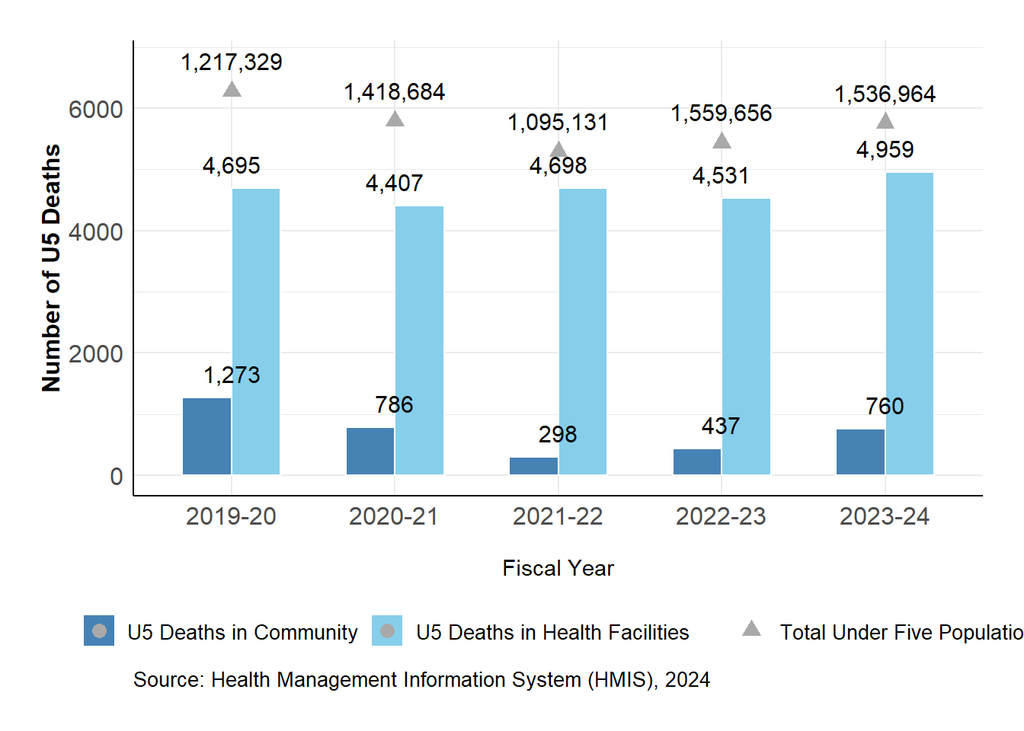

```r
data <- data.frame(
  Fiscal_Year = c("2019-20", "2020-21", "2021-22", "2022-23", "2023-24"),
  Children_6_59_months = c(1217329, 1418684, 1095131, 1559656, 1536964),
  U5_dealths_HFs = c(4695, 4407, 4698, 4531, 4959),
  U5_dealths_community = c(1273, 786, 298, 437, 760)
)

# Reshape data for side-by-side bar plot
data_long <- data %>%
  pivot_longer(cols = c(U5_dealths_HFs, U5_dealths_community),
               names_to = "Category",
               values_to = "Deaths")

# Bar plot
p <- ggplot(data_long) +
  # Bars for U5 deaths
  geom_bar(
    aes(x = Fiscal_Year, y = Deaths, fill = Category),
    stat = "identity", position = "dodge", color = "white", width = 0.6
  ) +
  # Red triangle to indicate total population only above community bars
  geom_point(
    data = data_long[data_long$Category == "U5_dealths_community", ],  # Only for community category
    aes(
      x = Fiscal_Year,
      y = Deaths + 5000,  # Position above the bars
      shape = "Total Under Five Population"
    ),
    color = "darkgrey", size = 3, show.legend = TRUE, vjust=-0.5
  ) +
  # Total population label at the top of each bar (for Community bars only)
  geom_text(
    data = data_long[data_long$Category == "U5_dealths_community", ],  # Only for community category
    aes(
      x = Fiscal_Year,
      y = Deaths + 5500,  # Adjusted position above the bars
      label = paste0(scales::comma(Children_6_59_months))  # Add commas
    ),
    size = 4, color = "black", family = "sans"
  ) +
  # Data label for U5 deaths at Health Facilities (only for HF bars)
  geom_text(
    data = data_long[data_long$Category == "U5_dealths_HFs", ],  # Only for HF category
    aes(
      x = Fiscal_Year,
      y = Deaths + 100,  # Position slightly above the top of the bars
      label = scales::comma(Deaths)  # Display number of deaths
    ),
    size = 4, color = "black", family = "sans", vjust = -0.5
  ) +
  # Data label for U5 deaths in the community (only for community bars)
  geom_text(
    data = data_long[data_long$Category == "U5_dealths_community", ],  # Only for community category
    aes(
      x = Fiscal_Year,
      y = Deaths + 100,  # Position slightly above the top of the bars
      label = scales::comma(Deaths)  # Display number of deaths
    ),
    size = 4, color = "black", family = "sans", vjust = -0.5
  ) +
  scale_fill_manual(
    values = c(
      "U5_dealths_HFs" = "#87CEEB",
      "U5_dealths_community" = "#4682B4"
    ),
    labels = c("U5 Deaths in Community", "U5 Deaths in Health Facilities")
  ) +
  scale_shape_manual(
    values = c("Total Under Five Population" = 17)  # Shape 17 is a triangle
  ) +
  # Labels and styling
  labs(
    x = "\nFiscal Year",
    y = "Number of U5 Deaths",
    fill = "Category",
    shape = "Indicator",
    caption = "Source: Health Management Information System (HMIS), 2024"
  ) +
  theme_minimal() +
  theme(
    axis.title.y = element_text(size = 12, face = "bold"),
    axis.text = element_text(size = 12),
    legend.position = "bottom",
    legend.title = element_blank(),
    legend.text = element_text(size = 10),
    axis.line = element_line(color = "black", size = 0.4),
    plot.caption = element_text(size = 10, hjust = 0),
    plot.background = element_rect(fill = "white", color = "white"),
    plot.margin = margin(20, 20, 20, 20)
  )
print(p)
```

Figure 7: Proportion of children 6-59 months screened for malnutrition (Weight-for-age) by CHWs

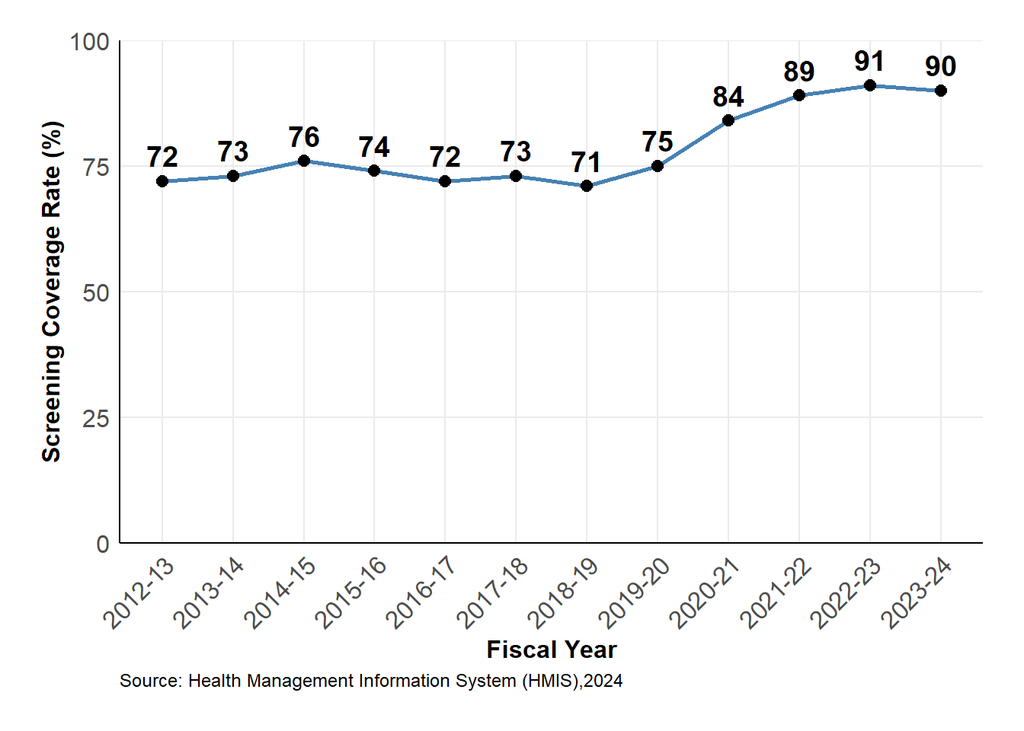

```r
data <- data.frame(
  Year = c("2012-13", "2013-14", "2014-15", "2015-16", "2016-17",
           "2017-18", "2018-19", "2019-20", "2020-21", "2021-22",
           "2022-23", "2023-24"),
  Children_screened = c(1001955, 1042804, 11166230, 1114858, 1123142,
                        1158317, 1152442, 1253883, 1438364, 1564784,
                        1572170, 1539364),
  Screening_coverage_rate = c(72, 73, 76, 74, 72, 73, 71, 75, 84, 89, 91, 90)
)

# Ensure 'Year' is treated as an ordered factor
data$Year <- factor(data$Year, levels = data$Year)

# Define plot texts as per SOP
caption_text <- "Source: Health Management Information System (HMIS),2024"

# Plot
p <- ggplot(data, aes(x = Year, y = Screening_coverage_rate, group = 1)) +
  # Line for coverage rate
  geom_line(color = "#4682B4", size = 1) +

  # Points for each year
  geom_point(color = "black", size = 2.5) +

  # Text labels above points
  geom_text(
    aes(label = Screening_coverage_rate),
    vjust = -0.7,
    size = 5,
    family = "sans",
    fontface = "bold",
    color = "black"
  ) +

  # Labels and theme
  labs(
    caption = caption_text,
    x = "Fiscal Year",
    y = "Screening Coverage Rate (%)"
  ) +

  # Apply SOP-compliant theme
  theme_minimal(base_family = "sans") +
  theme(
    axis.line = element_line(color = "black"),
    plot.caption = element_text(family = "sans", size = 9, hjust = 0),
    plot.title = element_text(family = "sans", size = 12, face = "bold", hjust = 0.5, margin = margin(b = 10)),
    axis.title.x = element_text(family = "sans", size = 12, face = "bold"),
    axis.title.y = element_text(family = "sans", size = 12, face = "bold"),
    axis.text = element_text(family = "sans", size = 12),

    # Remove legend
    legend.position = "none",

    # Panel grid and background
    panel.grid.minor = element_blank(),
    plot.background = element_rect(fill = "white", color = "white"),

    # Plot margins
    plot.margin = margin(20, 20, 20, 20)
  ) +

  # Y-axis scaling
  scale_y_continuous(limits = c(0, 100), expand = c(0, 0)) +

  # X-axis text rotation
  theme(axis.text.x = element_text(angle = 45, hjust = 1))

# Print the plot
print(p)
```

Figure 8: Moderate and severe acute malnutrition cases admitted in nutrition rehabilitation programme at health facilities

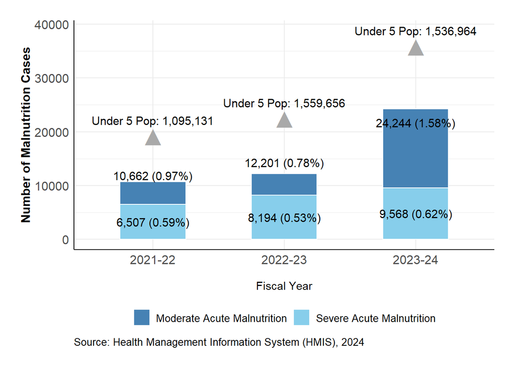

```r
data <- data.frame(
  Fiscal_Year = c("2021-22", "2022-23", "2023-24"),
  Children_6_59_months = c(1095131, 1559656, 1536964),
  Severe_Acute_Malnutrition = c(6507, 8194, 9568),
  Moderate_Acute_Malnutrition = c(10662, 12201, 24244)
)

# Data transformation
data1 <- data %>%
  mutate(
    Total_Cases = Severe_Acute_Malnutrition + Moderate_Acute_Malnutrition,
    Severe_Percentage = round((Severe_Acute_Malnutrition / Children_6_59_months) * 100, 2),
    Moderate_Percentage = round((Moderate_Acute_Malnutrition / Children_6_59_months) * 100, 2)
  )

# Bar plot
p <- ggplot(data1) +
  # Bars for Moderate Acute Malnutrition
  geom_bar(
    aes(x = Fiscal_Year, y = Moderate_Acute_Malnutrition, fill = "Moderate_Acute_Malnutrition"),
    stat = "identity", position = "stack", color = "white", width = 0.5
  ) +
  # Bars for Severe Acute Malnutrition
  geom_bar(
    aes(x = Fiscal_Year, y = Severe_Acute_Malnutrition, fill = "Severe_Acute_Malnutrition"),
    stat = "identity", position = "stack", color = "white", width = 0.5
  ) +
  # Red triangle to indicate total population
  geom_text(
    aes(
      x = Fiscal_Year,
      y = Total_Cases + 2000,  # Position above the bar
      label = "\u25B2"  # Unicode for triangle
    ),
    color = "darkgrey", size = 8, family = "sans"
  ) +
  # Total population label at the top of each bar
  geom_text(
    aes(
      x = Fiscal_Year,
      y = Total_Cases + 5000,  # Adjusted position
      label = paste0("Under 5 Pop: ", scales::comma(Children_6_59_months))  # Add commas
    ),
    size = 4, color = "black", family = "sans"
  ) +
  # Labels for Severe Acute Malnutrition with percentages
  geom_text(
    aes(
      x = Fiscal_Year,
      y = Severe_Acute_Malnutrition / 2,  # Center of Severe bar
      label = paste0(scales::comma(Severe_Acute_Malnutrition), " (", Severe_Percentage, "%)")
    ),
    size = 4, color = "black", family = "sans"
  ) +
  # Labels for Moderate Acute Malnutrition with percentages
  geom_text(
    aes(
      x = Fiscal_Year,
      y = Severe_Acute_Malnutrition + Moderate_Acute_Malnutrition / 2,  # Center of Moderate bar
      label = paste0(scales::comma(Moderate_Acute_Malnutrition), " (", Moderate_Percentage, "%)")
    ),
    size = 4, color = "black", family = "sans"
  ) +
  # Custom color scale for the two categories
  scale_fill_manual(
    values = c(
      "Severe_Acute_Malnutrition" = "#87CEEB",
      "Moderate_Acute_Malnutrition" = "#4682B4"
    ),
    labels = c("Moderate Acute Malnutrition", "Severe Acute Malnutrition")
  ) +
  # Labels and styling
  labs(
    x = "\nFiscal Year",
    y = "Number of Malnutrition Cases",
    fill = "Category",
    caption = "Source: Health Management Information System (HMIS), 2024"
  ) +
  theme_minimal() +
  theme(
    axis.title.y = element_text(size = 12, face = "bold"),
    axis.text = element_text(size = 12),
    legend.position = "bottom",
    legend.title = element_blank(),
    legend.text = element_text(size = 10),
    axis.line = element_line(color = "black", size = 0.4),
    plot.caption = element_text(size = 10, hjust = 0),
    plot.background = element_rect(fill = "white", color = "white"),
    plot.margin = margin(20, 20, 20, 20)
  )

# Display the plot
print(p)
```

Figure 9: Distribution of GBV cases reported by age group (FY 2023/24)

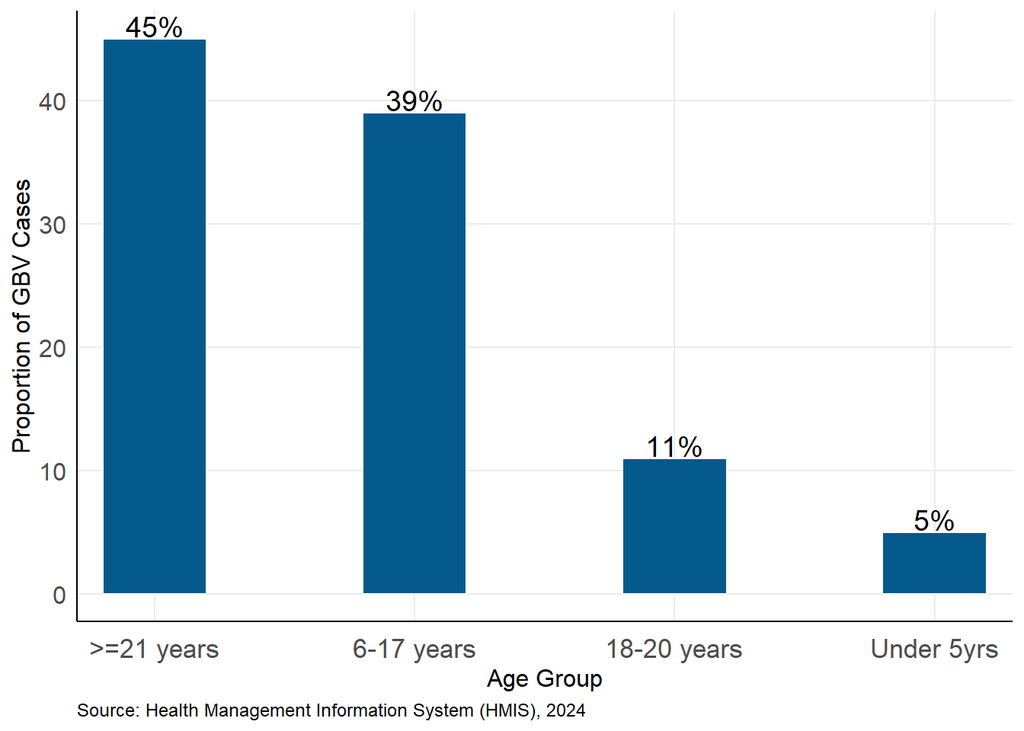

```r
data <- data.frame(
  Age = c("Under 5yrs", "6-17 years", "18-20 years", ">=21 years"),
  Percentage = c(5, 39, 11, 45)
)

data$Age <- factor(data$Age, levels = data$Age[order(-data$Percentage)])

g<-ggplot(data, aes(x = Age, y = Percentage)) +
  geom_bar(stat = "identity", width = 0.4, fill = "#045a8d", color = "white") +

  geom_text(aes(label = paste0(Percentage, "%")), vjust = -0.1, size = 5, color = "black") +

  labs(
    caption = "Source: Health Management Information System (HMIS), 2024",
    x = "Age Group",
    y = "Proportion of GBV Cases"
  ) +

  # Adjust theme
  theme_minimal() +
  theme(
    axis.text = element_text(size = 12),
    axis.title = element_text(size = 12),
    legend.position = "none",
    panel.grid.minor = element_blank(),
    axis.text.x = element_text(margin = margin(t = 5),size=13),
    axis.line = element_line(color = "black"),
        plot.caption = element_text(family = "sans", size = 9, hjust = 0)
  ) +

  scale_x_discrete(expand = c(0.1, 0))
print(g)
```

Figure 12: HIV testing and positivity rate

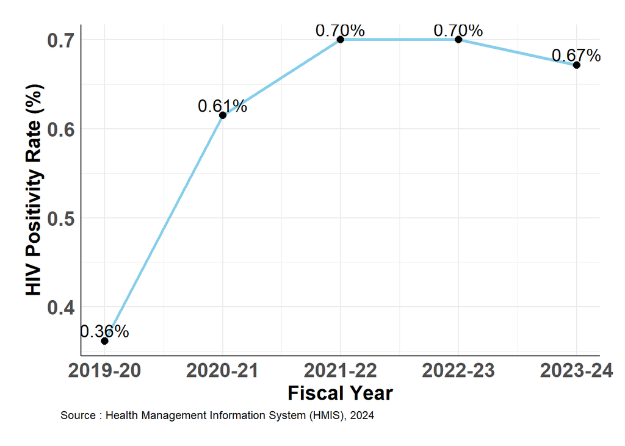

```r
# Data Preparation
data <- data.frame(
  Fiscal_Year = c("2019-20", "2020-21", "2021-22", "2022-23", "2023-24"),
  Total_Tested = c(3348337, 2632630, 2286931, 2072366, 1979852),
  Total_Positive = c(12110, 16190, 16009, 14507, 13296)
)

data$Positivity_Yield <- (data$Total_Positive / data$Total_Tested) * 100

# Convert Fiscal_Year to a continuous variable for reduced spacing
data$Year_Index <- seq_along(data$Fiscal_Year)

# Load necessary libraries
library(ggplot2)

# Plot
p <- ggplot(data, aes(x = Year_Index, y = Positivity_Yield, group = 1)) +
  geom_line(color = "skyblue", size = 1.2) +
  geom_point(color = "black", size = 2.5) +
  geom_text(
    aes(label = sprintf("%.2f%%", Positivity_Yield)),
    vjust = -0.3,
    size = 5,  # Larger font size for percentage labels
    family = "sans"
  ) +
  scale_x_continuous(
    breaks = data$Year_Index,
    labels = data$Fiscal_Year
  ) +
  labs(
    caption = "Source : Health Management Information System (HMIS), 2024",
    x = "Fiscal Year",
    y = "HIV Positivity Rate (%)"
  ) +
  theme_minimal() +
  theme(
    axis.title.x = element_text(size = 16, face = "bold", family = "sans"),
    axis.title.y = element_text(size = 16, face = "bold", family = "sans"),
    axis.text = element_text(size = 16, face = "bold", family = "sans"),
    plot.background = element_rect(fill = "white", color = "white"),
    plot.margin = margin(20, 20, 20, 20),
    axis.line = element_line(color = "black", size = 0.4),
        plot.caption = element_text(family = "sans", size = 9, hjust = -0.1)
  )

print(p)
```

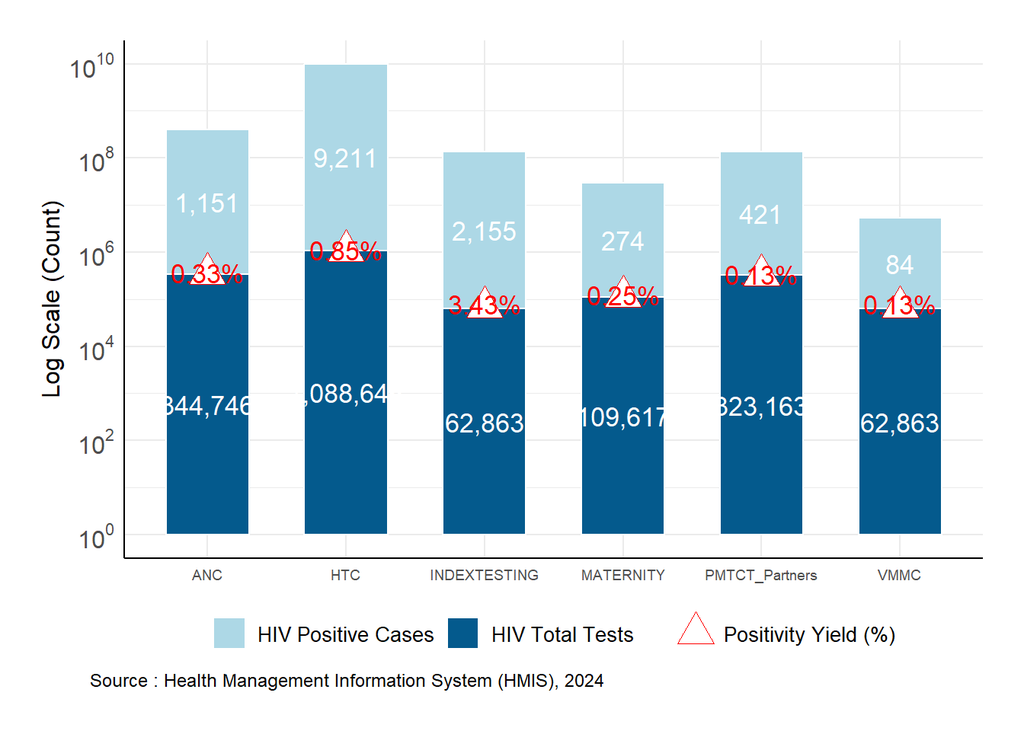

```r
# Load necessary libraries
library(ggplot2)
library(dplyr)
library(scales)
library(ggtext)

# Data preparation
data <- data.frame(
  Service = c("HTC", "ANC", "PMTCT_Partners", "MATERNITY", "VMMC", "INDEXTESTING"),
  Total_HIV_Tests = c(1088646, 344746, 323163, 109617, 62863, 62863),
  HIV_Positive_Cases = c(9211, 1151, 421, 274, 84, 2155)
) %>%
  mutate(Positivity_Yield = round((HIV_Positive_Cases / Total_HIV_Tests) * 100, 2))

# Reshape data for plotting
bar_data <- data %>%
  pivot_longer(cols = c(Total_HIV_Tests, HIV_Positive_Cases),
               names_to = "Category", values_to = "Count") %>%
  mutate(Category = ifelse(Category == "Total_HIV_Tests", "HIV Total Tests", "HIV Positive Cases"))

# Caption text
caption_text <- "Source : Health Management Information System (HMIS), 2024"

# Create the plot
p <- ggplot(bar_data, aes(x = Service, y = Count, fill = Category)) +
  geom_bar(stat = "identity", position = "stack", color = "white", width = 0.6) +
  geom_text(
    aes(label = scales::comma(Count)),
    position = position_stack(vjust = 0.5),
    size = 4.5,
    family = "sans",
    color = "white", face = "bold"
  ) +

  geom_point(
    data = data,
    aes(x = Service, y = Total_HIV_Tests + 5000, shape = "Positivity Yield (%)"),
    size = 6,
    color = "red", fill = "white",
    inherit.aes = FALSE
  ) +

  # Add labels for positivity yield near the triangles
  geom_text(
    data = data,
    aes(x = Service, y = Total_HIV_Tests + 15000, label = sprintf("%.2f%%", Positivity_Yield)),
    size = 4.5,
    family = "sans",
    color = "red",
    inherit.aes = FALSE
  ) +

  scale_fill_manual(
    values = c(
      "HIV Total Tests" = "#045a8d",
      "HIV Positive Cases" = "lightblue"
    )
  ) +

  scale_shape_manual(
    values = c("Positivity Yield (%)" = 24),  # Triangle shape
    name = NULL
  ) +

  labs(
    caption = caption_text,
    x = NULL,
    y = "Log Scale (Count)",
    fill = NULL
  ) +

  scale_y_continuous(
    trans = "log10",
    breaks = scales::trans_breaks("log10", function(x) 10^x),
    labels = scales::trans_format("log10", scales::math_format(10^.x))
  ) +

  # Add axis lines
  theme_minimal() +
  theme(
    axis.text = element_text(family = "sans", size = 12),
    axis.title.y = element_text(family = "sans", size = 12),
    axis.text.x = element_text(angle = 0, hjust = 0.5, size = 7),
    legend.position = "bottom",
    legend.title = element_text(family = "sans", size = 12, face = "bold"),
    legend.text = element_text(family = "sans", size = 10),
    legend.key.size = unit(0.6, "cm"),
    plot.title = element_textbox_simple(
      size = 20,
      family = "sans",
      face = "bold",
      hjust = 0.5,
      lineheight = 1.2,
      margin = margin(b = 10)
    ),
    plot.subtitle = element_text(
      size = 12, family = "sans", color = "grey15", hjust = 0.5
    ),
    plot.background = element_rect(fill = "white", color = "white"),
    plot.margin = margin(20, 20, 20, 20),
    axis.line = element_line(color = "black", size = 0.4),
        plot.caption = element_text(family = "sans", size = 9, hjust = -0.1)
  )
# Print the plot
print(p)
```

Figure 14: Viral Load Suppression from 2019 to 2024

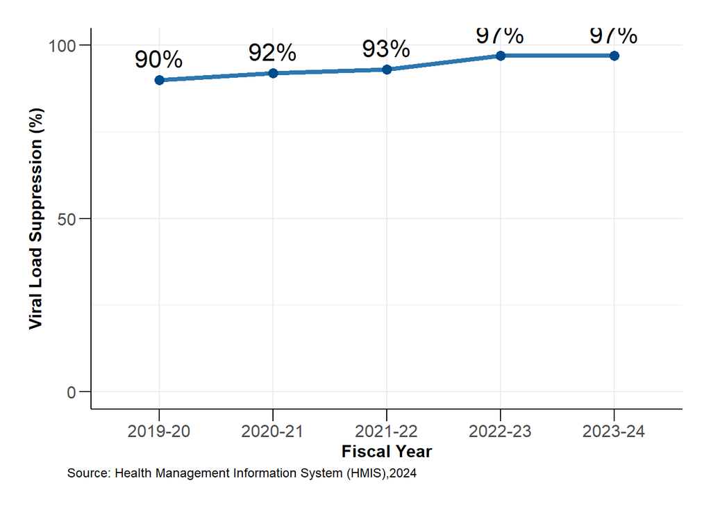

```r
# Libraries
library(ggplot2)

# Data
data <- data.frame(
  Year = c("2019-20", "2020-21", "2021-22", "2022-23", "2023-24"),
  Percentage = c(90, 92, 93, 97, 97)
)

# Fonts
title_font <- "sans"
body_font <- "sans"

# Visualization
f <- ggplot(data, aes(x = Year, y = Percentage, group = 1)) +
  geom_line(color = "#2C77B0", size = 1.5) +            # Line
  geom_point(color = "#004C8C", size = 3) +             # Points
  geom_text(aes(label = paste0(Percentage, "%")),       # Text labels
            vjust = -0.7, size = 6, family = body_font, color = "black") +
  labs(
    caption = "Source: Health Management Information System (HMIS),2024",
    x = "Fiscal Year",
    y = "Viral Load Suppression (%)"
  ) +
  scale_y_continuous(limits = c(0, 100), breaks = c(0, 50, 100)) +  # Y-axis: 0-50-100
  theme_minimal() +
  theme(
    # Titles
    plot.title = element_text(family = title_font, size = 26, face = "bold", hjust = 0.5),
    plot.subtitle = element_text(family = body_font, size = 22, hjust = 0.5),
    # Axis
    axis.title.y = element_text(family = body_font, size = 12, face = "bold"),
    axis.title.x = element_text(family = body_font, size = 12, face = "bold"),
    axis.text = element_text(family = body_font, size = 12),       # Add axis lines
    axis.ticks = element_line(color = "black"),                 # Ticks on axes
    axis.ticks.length = unit(0.3, "cm"),
    plot.margin = margin(20, 20, 20, 20),
   axis.line = element_line(color = "black", size = 0.4),
        plot.caption = element_text(family = "sans", size = 9, hjust = -0.1),
  )

# Display
print(f)
```

Figure 15: Trend of ART Coverage Among PLHIV from 2019 to 2024

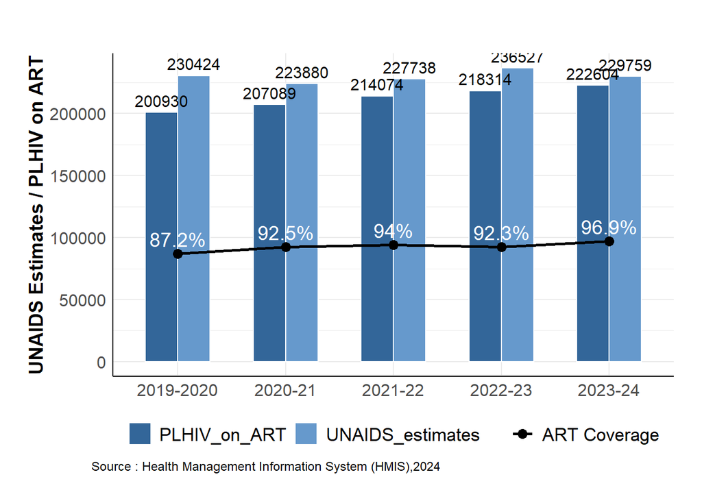

```r
data <- data.frame(
  Year = c("2019-2020", "2020-21", "2021-22", "2022-23", "2023-24"),
  UNAIDS_estimates = c(230424, 223880, 227738, 236527, 229759),
  PLHIV_on_ART = c(200930, 207089, 214074, 218314, 222604),
  ART_Coverage = c(87.2, 92.5, 94.0, 92.3, 96.9)
)

bar_data <- data %>%
  pivot_longer(cols = c(UNAIDS_estimates, PLHIV_on_ART), names_to = "Type", values_to = "Count")

o <- ggplot() +
  geom_bar(
    data = bar_data,
    aes(x = Year, y = Count, fill = Type),
    stat = "identity",
    position = "dodge",
    color = "white",
    width = 0.6
  ) +
  geom_text(
    data = bar_data,
    aes(x = Year, y = Count, label = Count, group = Type),
    position = position_dodge(width = 0.6),
    size = 4,
    color = "black",
    vjust = -0.5
  ) +
  geom_line(
    data = data,
    aes(x = Year, y = ART_Coverage * 1000, group = 1, color = "ART Coverage"),
    size = 0.9
  ) +
  geom_point(
    data = data,
    aes(x = Year, y = ART_Coverage * 1000, color = "ART Coverage"),
    size = 3
  ) +
  geom_text(
    data = data,
    aes(x = Year, y = ART_Coverage * 1000, label = paste0(ART_Coverage, "%")),
    vjust = -0.5,
    size = 5,
    color = "white"
  ) +
  scale_y_continuous(
    name = "UNAIDS Estimates / PLHIV on ART"
  ) +
  scale_fill_manual(values = c("UNAIDS_estimates" = "#6699CC", "PLHIV_on_ART" = "#336699")) +
  scale_color_manual(values = c("ART Coverage" = "black")) +
  labs(caption="Source : Health Management Information System (HMIS),2024",
    subtitle = "",
    x = NULL,
    fill = "Type",
    color = NULL
  ) +
  theme_minimal() +
  theme(
    axis.title.y = element_text(size = 14, face = "bold"),
    axis.text = element_text(size = 12),
    legend.position = "bottom",
    legend.title = element_blank(),
    legend.text = element_text(size = 13),
    plot.title = element_text(size = 20, face = "bold", hjust = 0.5),
    plot.subtitle = element_text(size = 14, color = "grey15", hjust = 0.5),
    plot.background = element_rect(fill = "white", color = "white"),
    plot.margin = margin(20, 20, 20, 20),
 axis.line = element_line(color = "black", size = 0.4),
        plot.caption = element_text(family = "sans", size = 9, hjust = -0.1)
  )

print(o)
```

Figure 15: Hepatitis B prevention, care and Treatment FY 2023/24

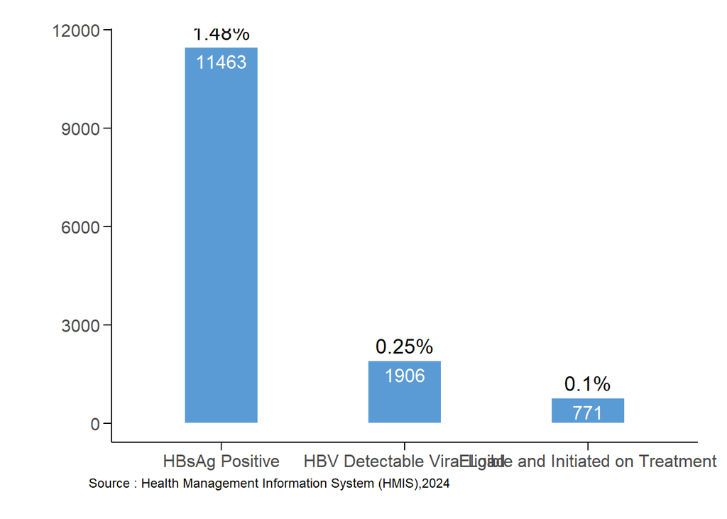

```r
# Data
data <- data.frame(
  Category = c("HBsAg Positive", "HBV Detectable Viral Load", "Eligible and Initiated on Treatment"),
  Total = c(11463, 1906, 771),
  Percentage = c(1.48, 0.25, 0.10)
)

# Sort bars by total values
data$Category <- reorder(data$Category, -data$Total)

# Fonts
title_font <- "sans"
body_font <- "sans"

# Plot
ggplot(data, aes(x = Category, y = Total, fill = Category)) +
  geom_bar(stat = "identity", width = 0.4, color = "white", show.legend = FALSE) +

  # Add percentage labels above the bars
  geom_text(aes(label = paste0(Percentage, "%")),
            vjust = -0.5, size = 5, family = body_font, color = "black") +

  # Add total labels inside the bars
  geom_text(aes(label = Total),
            vjust = 1.5, size = 4.5, family = body_font, color = "white") +

  labs(
    caption = "Source : Health Management Information System (HMIS),2024",
    x = NULL,
    y = ""
  ) +

  scale_fill_manual(values = c("#5B9BD5", "#5B9BD5", "#5B9BD5")) +

  theme_minimal() +
  theme(
    axis.title.y = element_text(family = body_font, size = 14, face = "bold"),
    axis.text = element_text(family = body_font, size = 12),
    axis.text.x = element_text(angle = 0, hjust = 0.5),
    axis.line = element_line(color = "black", size = 0.4),     # Add axis lines
    axis.ticks = element_line(color = "black"),               # Ticks on axes
    axis.ticks.length = unit(0.2, "cm"),                      # Length of ticks
    # Grid
    panel.grid = element_blank(),
    # Caption and margins
    plot.caption = element_text(family = body_font, size = 9, hjust = -0.1),
    plot.margin = margin(20, 20, 20, 20)
  )
```

Figure 15: Individuals diagnosed and treated for STIs, 2019-2024

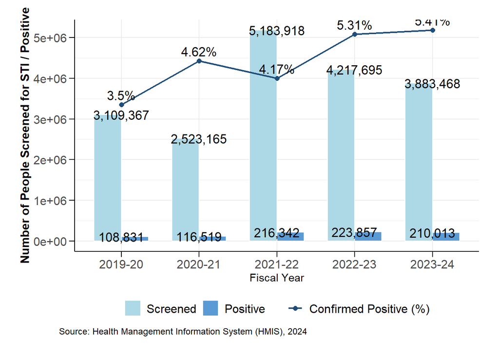

```r
library(ggplot2)
library(dplyr)
library(tidyr)
library(scales)

# Data Preparation
data <- data.frame(
  Year = c("2019-20", "2020-21", "2021-22", "2022-23", "2023-24"),
  Number_Clients_Screened_for_STI = c(3109367, 2523165, 5183918, 4217695, 3883468),
  Number_Clients_with_Positive_STI = c(108831, 116519, 216342, 223857, 210013)
) %>%
  mutate(Percentage_Confirmed_Positive_STI = (Number_Clients_with_Positive_STI / Number_Clients_Screened_for_STI) * 100)

# Pivot Data for Bar Plot
bar_data <- data %>%
  pivot_longer(cols = c(Number_Clients_Screened_for_STI, Number_Clients_with_Positive_STI),
               names_to = "Category",
               values_to = "Count") %>%
  mutate(Category = factor(Category, levels = c(
    "Number_Clients_Screened_for_STI",
    "Number_Clients_with_Positive_STI"
  )))

caption_text <- "Source: Health Management Information System (HMIS), 2024"

# Plot
p <- ggplot() +
  # Bar plot for screened and positive clients
  geom_bar(data = bar_data,
           aes(x = Year, y = Count, fill = Category),
           stat = "identity",
           position = "dodge",
           color = "white",
           width = 0.7) +

  # Text labels for bar values with commas
  geom_text(data = bar_data,
            aes(x = Year, y = Count, label = scales::comma(Count)),
            position = position_dodge(width = 0.7),
            family = "sans",
            size = 4.5,
            color = "black", hjust = 0.5) +

  # Line plot for percentage confirmed positive
  geom_line(data = data,
            aes(x = Year,
                y = Percentage_Confirmed_Positive_STI * max(bar_data$Count) / max(data$Percentage_Confirmed_Positive_STI),
                color = "Confirmed Positive (%)", group = 1),
            size = 0.8) +

  # Points for percentage confirmed positive
  geom_point(data = data,
             aes(x = Year,
                 y = Percentage_Confirmed_Positive_STI * max(bar_data$Count) / max(data$Percentage_Confirmed_Positive_STI),
                 color = "Confirmed Positive (%)"),
             size = 2) +

  # Text labels for percentage values
  geom_text(data = data,
            aes(x = Year,
                y = Percentage_Confirmed_Positive_STI * max(bar_data$Count) / max(data$Percentage_Confirmed_Positive_STI),
                label = paste0(round(Percentage_Confirmed_Positive_STI, 2), "%")),
            vjust = -0.5,
            family = "sans",
            size = 4.5,
            color = "black") +

  # Customize y-axis for the unified scale
  scale_y_continuous(name = "Number of People Screened for STI / Positive") +

  # Define colors and legend labels
  scale_fill_manual(
    name = "Category",
    values = c(
      "Number_Clients_Screened_for_STI" = "lightblue",
      "Number_Clients_with_Positive_STI" = "#5B9BD5"
    ),
    labels = c("Screened", "Positive")
  ) +
  scale_color_manual(
    name = "Category",
    values = c("Confirmed Positive (%)" = "#1F4E79"),
    breaks = c("Confirmed Positive (%)"),  # Ensure the percentage line comes last
    labels = c("Confirmed Positive (%)")
  ) +

  # Add axis lines and other adjustments
  theme_minimal() +
  theme(
    axis.title.y = element_text(family = "sans", size = 12, face = "bold"),
    axis.text = element_text(family = "sans", size = 12),
    axis.line = element_line(color = "black", size = 0.4),
    axis.ticks = element_line(color = "black"),
    axis.ticks.length = unit(0.2, "cm"),
    legend.position = "bottom",
    legend.title = element_blank(),
    legend.text = element_text(family = "sans", size = 12),
    plot.caption = element_text(family = "sans", size = 9, hjust = -0.1),
    plot.title = element_textbox_simple(size = 20, family = "sans", face = "bold", hjust = 0.5),
    plot.subtitle = element_text(size = 14, family = "sans", color = "grey15", hjust = 0.5),
    plot.background = element_rect(fill = "white", color = "white"),
    plot.margin = margin(20, 20, 20, 20)
  ) +

  labs(
    caption = caption_text,
    x = "Fiscal Year",
    y = "Count"
  )

print(p)
```

Figure 15: Individuals diagnosed and treated for TB and Leprosy, 2024

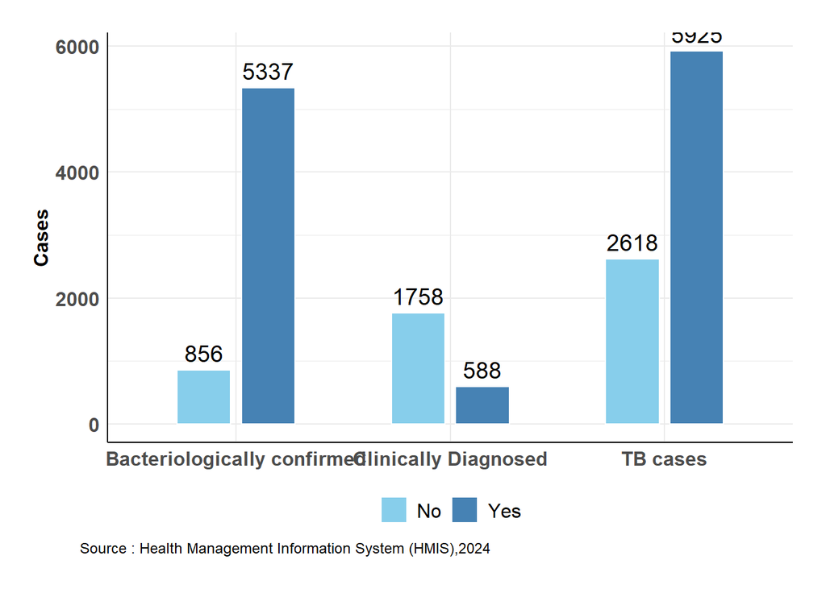

```r
data <- data.frame(
  Category = c("Bacteriologically confirmed", "Clinically Diagnosed", "TB cases"),
  No = c(856, 1758, 2618),
  Yes = c(5337, 588, 5925)
)

# Reshape data for grouped bar plot
library(tidyr)
bar_data <- data %>%
  pivot_longer(cols = c(No, Yes), names_to = "Response", values_to = "Count")

title_font <- "sans"
body_font <- "sans"

# Define caption
caption_text <- "Source: HMIS"

# Plot
p <- ggplot(bar_data, aes(x = Category, y = Count, fill = Response)) +
  # Grouped bar plot
  geom_bar(stat = "identity", position = position_dodge(width = 0.6), color = "white", width = 0.5) +
  # Labels on bars
  geom_text(
    aes(label = Count),
    position = position_dodge(width = 0.6),
    vjust = -0.5,
    family = body_font,
    size = 5,
    color = "black"
  ) +
  # Scaling and colors
  scale_fill_manual(
    values = c("No" = "#87CEEB", "Yes" = "#4682B4")
  ) +
  # Labels and theme
  labs(
    x = NULL,
    y = "Cases",
    fill = NULL,
    caption = "Source : Health Management Information System (HMIS),2024"
  ) +
  theme_minimal() +
  theme(
    axis.title.y = element_text(family = body_font, size = 12, face = "bold"),
    axis.text = element_text(family = body_font, size = 12, face = "bold"),
    axis.text.x = element_text(angle = 0, hjust = 0.5, vjust = 1),
     axis.line = element_line(color = "black", size = 0.4),
    plot.caption = element_text(family = "sans", size = 9, hjust = -0.1),
    legend.position = "bottom",
    legend.text = element_text(family = body_font, size = 12),
    plot.background = element_rect(fill = "white", color = "white"),
    plot.margin = margin(20, 20, 20, 20)
  )

print(p)
```

Figure 15: Malaria incidence per 1000 persons Year, FY 2017/18 - FY 2023/24

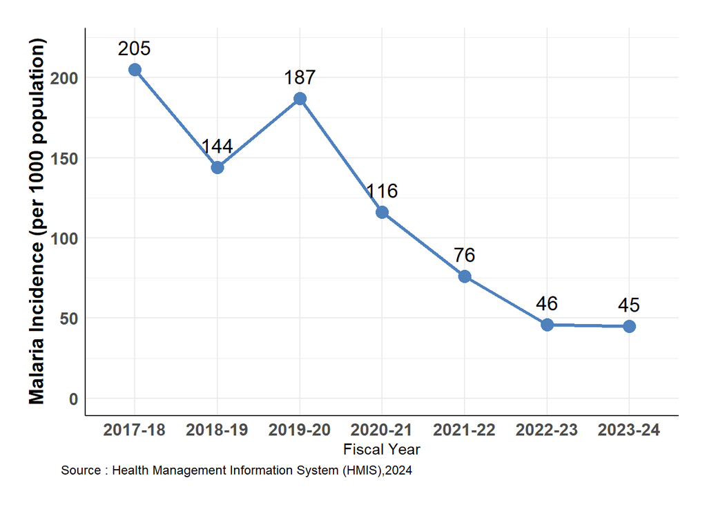

```r
# Data preparation
data <- data.frame(
  Period = c("2017-18", "2018-19", "2019-20", "2020-21", "2021-22", "2022-23", "2023-24"),
  Malaria_Incidence = c(205, 144, 187, 116, 76, 46, 45)
)

# Font settings
body_font <- "body_font"

# Plot
library(ggplot2)

p <- ggplot(data, aes(x = Period, y = Malaria_Incidence, group = 1)) +
  geom_line(color = "#4F81BD", size = 1.2) + # Blue line
  geom_point(color = "#4F81BD", size = 4) + # Points on the line
  geom_text(
    aes(label = Malaria_Incidence),
    vjust = -1, size = 5, family = body_font, color = "black"
  ) +
  labs(caption = "Source : Health Management Information System (HMIS),2024",
    x = "Fiscal Year",
    y = "Malaria Incidence (per 1000 population)"
  ) +
  scale_y_continuous(limits = c(0, 220)) +
  theme_minimal() +
  theme(
    axis.text = element_text(family = body_font, size = 12, face = "bold"),
    axis.line = element_line(color = "black", size = 0.4),
    axis.title.y = element_text(family = body_font, size = 14, face = "bold"),
     plot.caption = element_text(family = "sans", size = 9, hjust = -0.1),
    legend.position = "none", # No legend for a single line graph
    plot.background = element_rect(fill = "white", color = "white"),
    plot.margin = margin(20, 20, 20, 20)
  )

print(p)
```

Figure 15: Order fill rate (%) from Jan-June 2024

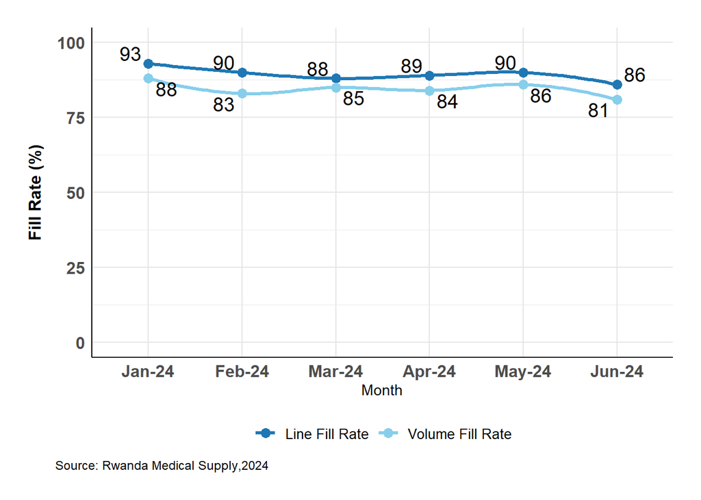

```r
data <- data.frame(
  Month = factor(c("Jan-24", "Feb-24", "Mar-24", "Apr-24", "May-24", "Jun-24"), levels = c("Jan-24", "Feb-24", "Mar-24", "Apr-24", "May-24", "Jun-24")),
  Line_Fill_Rate = c(93, 90, 88, 89, 90, 86),
  Volume_Fill_Rate = c(88, 83, 85, 84, 86, 81)
)

# Reshape data for plotting
data_long <- tidyr::pivot_longer(
  data,
  cols = c(Line_Fill_Rate, Volume_Fill_Rate),
  names_to = "RateType",
  values_to = "FillRate"
)

# Define colors
colors <- c(
  "Line_Fill_Rate" = "#1F78B4",  # Blue
  "Volume_Fill_Rate" = "#87CEEB"  # Light Blue
)

# Plot
p <- ggplot(data_long, aes(x = Month, y = FillRate, color = RateType, group = RateType)) +
  # Smooth lines
  geom_smooth(method = "loess", se = FALSE, size = 1.2) +
  # Points for each rate type
  geom_point(size = 3) +
  # Labels for data points
  geom_text_repel(
    aes(label = round(FillRate, 1)),
    size = 5,
    family = "sans",
    color = "black",
    show.legend = FALSE
  ) +
  # Custom colors
  scale_color_manual(values = colors, labels = c("Line Fill Rate", "Volume Fill Rate")) +
  # Set y-axis limits starting from 0
  scale_y_continuous(limits = c(0, 100)) +
  # Axis labels and caption
  labs(
    x = "Month",
    y = "Fill Rate (%)",
    caption = "Source: Rwanda Medical Supply,2024"
  ) +
  # Theme customization
  theme_minimal() +
  theme(
    axis.text = element_text(family = "sans", size = 12, face = "bold"),
    axis.title.y = element_text(family = "sans", size = 12, face = "bold", margin = margin(r = 10)),
    legend.title = element_blank(),
    axis.line = element_line(color = "black", size = 0.4),
    legend.position = "bottom",
    plot.caption = element_text(family = "sans", size = 9, hjust = -0.1),
    legend.text = element_text(family = "sans", size = 10),
    plot.margin = margin(20, 20, 20, 20),
    panel.grid.major = element_line(color = "grey90")
  ) +
  # Adjust legend to a single row
  guides(color = guide_legend(nrow = 1, byrow = TRUE))

print(p)
```

Figure 15: Proportion of water and electricity in the health facilities, June 2024

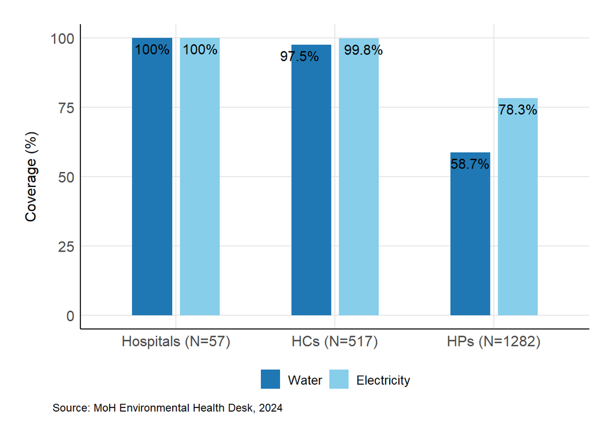

```r
# Load necessary libraries
library(ggplot2)
library(ggrepel)
library(showtext)


# Data preparation
data <- data.frame(
  Labels = rep(c("Hospitals (N=57)", "HCs (N=517)", "HPs (N=1282)"), each = 2),
  Percentages = c(100, 100, 97.5, 99.8, 58.7, 78.3),  # Water and Electricity percentages
  Utility = rep(c("Water", "Electricity"), times = 3)
)

# Convert Labels and Utility to factors with desired order
data$Labels <- factor(data$Labels, levels = c("Hospitals (N=57)", "HCs (N=517)", "HPs (N=1282)"))
data$Utility <- factor(data$Utility, levels = c("Water", "Electricity"))

# Define colors for utilities
colors <- c("Water" = "#1F78B4", "Electricity" = "#87CEEB")

# Plot
p <- ggplot(data, aes(x = Labels, y = Percentages, fill = Utility)) +
  # Side-by-side bars
  geom_bar(stat = "identity", position = position_dodge(width = 0.6), width = 0.5) +
  # Labels above bars
  geom_text_repel(
    aes(label = paste0(Percentages, "%")),
    position = position_dodge(width = 0.6),
    vjust = -0.5,
    size = 4,
    family = "sans",
    color = "black",
    show.legend = FALSE
  ) +
  # Custom colors
  scale_fill_manual(values = colors, labels = c("Water", "Electricity")) +
  # Axis labels and caption
  labs(
    x = NULL,
    y = "Coverage (%)",
    caption = "Source: MoH Environmental Health Desk, 2024"
  ) +
  # Theme customization
  theme_minimal() +
  theme(axis.line = element_line(color = "black", size = 0.4),
        plot.caption = element_text(family = "sans", size = 9, hjust = -0.1),
    axis.text = element_text(family = "sans", size = 12),
    axis.title.y = element_text(family = "sans", size = 12, margin = margin(r = 10)),
    legend.title = element_blank(),
    legend.position = "bottom",
    legend.text = element_text(family = "sans", size = 10),
    plot.margin = margin(20, 20, 20, 20),
    panel.grid.major = element_line(color = "grey90"),
    panel.grid.minor = element_blank()
  ) +
  # Adjust legend to a single row
  guides(fill = guide_legend(nrow = 1, byrow = TRUE))

print(p)
```

Figure 15: Blood Collection sessions performed in FY2023/24

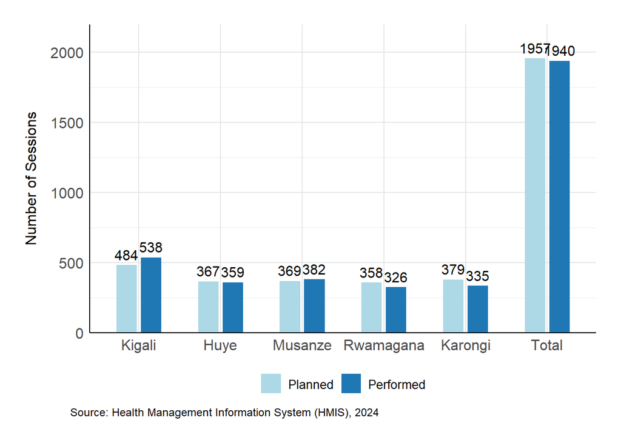

```r
# Load necessary libraries
library(ggplot2)
library(ggrepel)
library(showtext)

data <- data.frame(
  Location = rep(c("Kigali", "Huye", "Musanze", "Rwamagana", "Karongi", "Total"), each = 2),
  Sessions = c(484, 538,  # Kigali: Planned, Performed
               367, 359,  # Huye: Planned, Performed
               369, 382,  # Musanze: Planned, Performed
               358, 326,  # Rwamagana: Planned, Performed
               379, 335,  # Karongi: Planned, Performed
               1957, 1940), # Total: Planned, Performed
  Type = rep(c("Planned", "Performed"), times = 6)
)

# Convert Location to a factor to control the order in the plot
data$Location <- factor(data$Location, levels = c("Kigali", "Huye", "Musanze", "Rwamagana", "Karongi", "Total"))

# Reorder Type to ensure "Planned" comes first
data$Type <- factor(data$Type, levels = c("Planned", "Performed"))

# Define custom colors
colors <- c("Planned" = "lightblue", "Performed" = "#1F77B4")

# Create the side-by-side bar plot
p <- ggplot(data, aes(x = Location, y = Sessions, fill = Type)) +
  # Bars
  geom_bar(stat = "identity", position = position_dodge(width = 0.6), width = 0.5) +
  # Labels
  geom_text(
    aes(label = Sessions),
    position = position_dodge(width = 0.6),
    vjust = -0.5,
    size = 4,
    family = "body_font"
  ) +
  # Custom colors
  scale_fill_manual(values = colors) +
  # Y-axis limits starting from zero
  scale_y_continuous(expand = expansion(mult = c(0, 0.1)), limits = c(0, 2000)) +
  # Axis labels and caption
  labs(
    x = NULL,  # Remove x-axis label
    y = "Number of Sessions",
    caption = "Source: Health Management Information System (HMIS), 2024"
  ) +
  # Theme customization
  theme_minimal() +
  theme(axis.line = element_line(color = "black", size = 0.4),
        plot.caption = element_text(family = "sans", size = 9, hjust = -0.1),
    axis.text = element_text(family = "sans", size = 12),
    axis.title.y = element_text(family = "sans", size = 12, margin = margin(r = 10)),
    legend.title = element_blank(),
    legend.position = "bottom",
    legend.text = element_text(family = "sans", size = 10),
    plot.margin = margin(20, 20, 20, 20),
    panel.grid.major = element_line(color = "grey90")
  ) +
  # Adjust legend to a single row
  guides(fill = guide_legend(nrow = 1, byrow = TRUE))

print(p)
```

Figure 15: Annual trends of OPD visits per capita compared to population

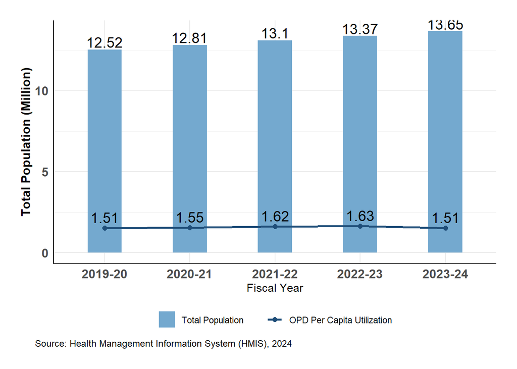

```r
# Load necessary libraries
library(ggplot2)
library(tidyr)

# Create the data frame
data <- data.frame(
  Fiscal_Year = c("2019-20", "2020-21", "2021-22", "2022-23", "2023-24"),
  Total_Population_Million = c(12.52, 12.81, 13.10, 13.37, 13.65),
  OPD_Per_Capita_Utilization_Ratio = c(1.51, 1.55, 1.62, 1.63, 1.51)
)

# Plot
ggplot(data, aes(x = Fiscal_Year)) +

  # Bar plot for Total Population (Million)
  geom_bar(aes(y = Total_Population_Million, fill = "Total Population"),
           stat = "identity", position = "dodge", width = 0.4) +

  # Line plot for OPD Per Capita Utilization (Ratio)
  geom_line(aes(y = OPD_Per_Capita_Utilization_Ratio,
                group = 1, color = "OPD Per Capita Utilization"),
            size = 1) +

  # Points for OPD Per Capita Utilization (Ratio)
  geom_point(aes(y = OPD_Per_Capita_Utilization_Ratio,
                 color = "OPD Per Capita Utilization"), size = 2) +

  # Text labels for OPD Per Capita Utilization (Ratio)
  geom_text(aes(y = OPD_Per_Capita_Utilization_Ratio,
                label = round(OPD_Per_Capita_Utilization_Ratio, 2)),
            vjust = -0.5, size = 5, color = "black") +

  # Text labels on bars for Total Population
  geom_text(aes(y = Total_Population_Million,
                label = round(Total_Population_Million, 2)),
            position = position_dodge(width = 0.7),
            vjust = -0.2, size = 5, color = "black") +

  # Customize y-axis for Total Population (Million)
  scale_y_continuous(name = "Total Population (Million)") +

  # Color settings for the bars and line
  scale_fill_manual(values = c("Total Population" = "#74a9cf")) +
  scale_color_manual(values = c("OPD Per Capita Utilization" = "#1F4E79")) +

  # Labels and theme customization
  labs(
    x = "Fiscal Year",
    y = NULL,
    fill = NULL,  # Remove the "Legend" label from the fill legend
    color = NULL, # Remove the "Legend" label from the color legend
    caption = "Source: Health Management Information System (HMIS), 2024"
  ) +
  theme_minimal() +
  theme(
    axis.line = element_line(color = "black", size = 0.4),
    plot.caption = element_text(family = "sans", size = 9, hjust = -0.1),
    axis.title.y = element_text(size = 12, face = "bold"),
    axis.text = element_text(size = 12, face = "bold"),
    legend.position = "bottom",
    plot.title = element_text(size = 14, face = "bold", hjust = 0.5),
    plot.subtitle = element_text(size = 12, hjust = 0.5),
    plot.background = element_rect(fill = "white", color = "white"),
    plot.margin = margin(20, 20, 20, 20)
  )
```

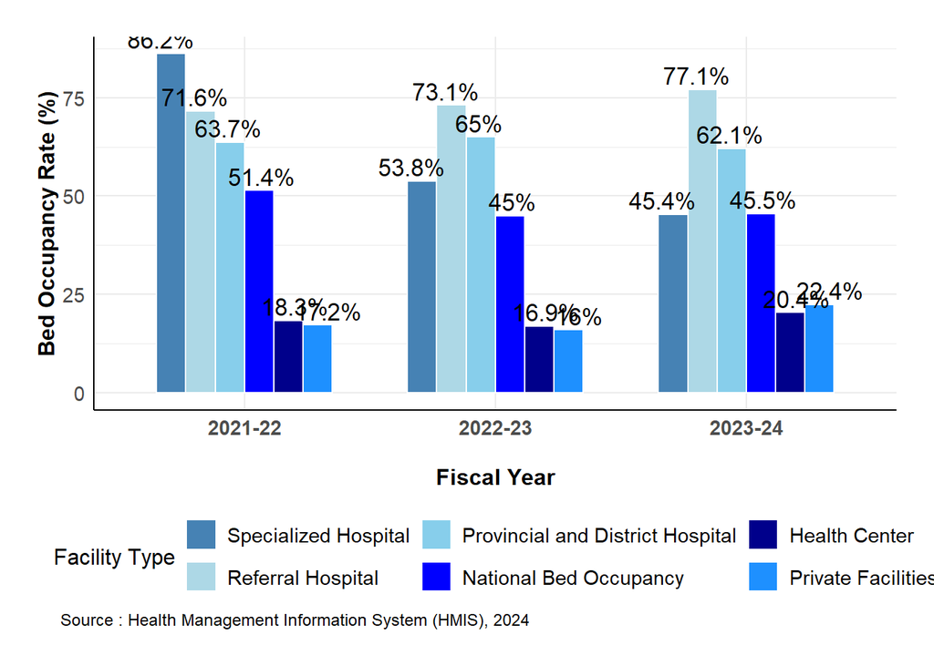

```r
library(ggplot2)
library(reshape2)
library(stringr)

# Prepare the data
fiscal_years <- c("2021-22", "2022-23", "2023-24")
provincial_hospital <- c(63.70, 65.00, 62.10)
health_center <- c(18.30, 16.90, 20.40)
referral_hospital <- c(71.60, 73.10, 77.10)
specialized_hospital <- c(86.20, 53.80, 45.40)
private_facilities <- c(17.20, 16.00, 22.40)
national_bed_occupancy <- c(51.40, 45.00, 45.50)

# Combine data into a long format
data <- data.frame(
  Fiscal_Year = fiscal_years,
  Provincial_and_District_Hospital = provincial_hospital,
  Health_Center = health_center,
  Referral_Hospital = referral_hospital,
  Specialized_Hospital = specialized_hospital,
  Private_Facilities = private_facilities,
  National_Bed_Occupancy = national_bed_occupancy
)

data_long <- melt(data, id.vars = "Fiscal_Year", variable.name = "Facility_Type", value.name = "Occupancy_Rate")

# Remove underscores for better legend display
data_long$Facility_Type <- str_replace_all(data_long$Facility_Type, "_", " ")

# Sort by Fiscal_Year and Occupancy_Rate
data_long <- data_long[order(data_long$Fiscal_Year, -data_long$Occupancy_Rate), ]

# Convert Facility_Type to a factor with the correct order
data_long$Facility_Type <- factor(data_long$Facility_Type, levels = unique(data_long$Facility_Type))

# Plot
p <- ggplot(data_long, aes(x = Fiscal_Year, y = Occupancy_Rate, fill = Facility_Type)) +
  geom_bar(stat = "identity", position = "dodge", color = "white", width = 0.7) +
  geom_text(
    aes(label = paste0(Occupancy_Rate, "%")),
    position = position_dodge(width = 0.8),
    vjust = -0.3,
    family = body_font,
    size = 4.5,
    color = "black"
  ) +
  scale_fill_manual(
    values = c(
      "Provincial and District Hospital" = "#87CEEB",
      "Health Center" = "darkblue",
      "Referral Hospital" = "lightblue",
      "Specialized Hospital" = "#4682B4",
      "Private Facilities" = "#1E90FF",
      "National Bed Occupancy" = "#0000FF"
    )
  ) +
  labs(
    x = "\nFiscal Year",
    y = "Bed Occupancy Rate (%)",
    fill = "Facility Type",
    caption = "Source : Health Management Information System (HMIS), 2024"
  ) +
  theme_minimal() +
  theme(
    axis.line = element_line(color = "black", size = 0.4),
    plot.caption = element_text(family = "sans", size = 9, hjust = -0.1),
    axis.title.y = element_text(family = body_font, size = 12, face = "bold"),
    axis.title.x = element_text(family = body_font, size = 12, face = "bold"),
    axis.text = element_text(family = body_font, size = 11),
    axis.text.x = element_text(family = body_font, size = 11, face = "bold"),
    legend.position = "bottom",
    legend.title = element_text(family = body_font, size = 12),
    legend.text = element_text(family = body_font, size = 11),
    plot.background = element_rect(fill = "white", color = "white"),
    plot.margin = margin(20, 20, 20, 20)
  )

# Print the plot
print(p)
```

```r
#ggsave("C:/Users/GK TECH/Desktop/PNG_Graphs/BedOccupancy1.png", plot = p, width = 6, height = 4, dpi = 300)
```

Figure 15: Bed occupancy Rate by Department for the Fiscal Year 2023-24

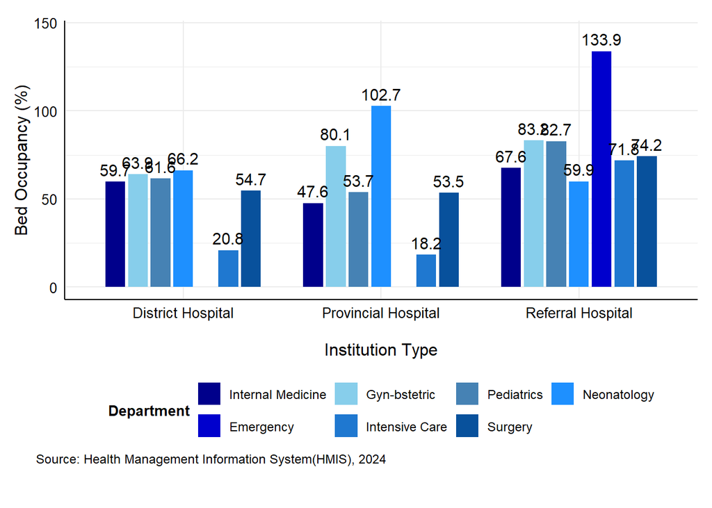

```r
categories <- c("District Hospital", "Provincial Hospital", "Referral Hospital")
departments <- c("Internal Medicine", "Gyn-bstetric", "Pediatrics",
                 "Neonatology", "Emergency", "Intensive Care", "Surgery")

data <- data.frame(
  Category = rep(categories, each = length(departments)),
  Department = factor(rep(departments, times = length(categories)), levels = departments),
  Coverage = c(59.7, 63.9, 61.6, 66.2, 0.0, 20.8, 54.7,
               47.6, 80.1, 53.7, 102.7, 0.0, 18.2, 53.5,
               67.6, 83.2, 82.7, 59.9, 133.9, 71.8, 74.2)
)

# Define custom colors
colors <- c("#00008B", "skyblue", "steelblue",
            "#1E90FF",  "#0000CD", "#1F78D0", "#08519C")

# Create the plot
p_map<-ggplot(data, aes(x = Category, y = Coverage, fill = Department)) +
  geom_bar(stat = "identity", position = position_dodge(width = 0.8), width = 0.7) +
  geom_text(
    aes(label = ifelse(Coverage > 0, round(Coverage, 1), "")), # Add labels for non-zero values
    position = position_dodge(width = 0.8),
    vjust = -0.5,  # Position above the bars
    size = 4       # Adjust font size for the text
  ) +
  ylim(0, max(data$Coverage) + 10) +  # Add extra space above the highest value
  scale_fill_manual(values = colors) +
  theme_minimal(base_family = "sans") +  # Apply sans-serif font
  theme(axis.line = element_line(color = "black", size = 0.4),
        plot.caption = element_text(family = "sans", size = 9, hjust = -0.1),

    axis.text = element_text(size = 10, color = "black"),
    axis.title = element_text(size = 12, color = "black"),
    legend.position = "bottom",
    legend.title = element_text(size = 10, face = "bold"),
    legend.text = element_text(size = 9),
    plot.margin = margin(15, 10, 30, 10) # Add space for the source
  ) +
  labs(
    x = "\nInstitution Type",
    y = "Bed Occupancy (%)",
    fill = "Department",
    caption = "Source: Health Management Information System(HMIS), 2024"
  ) +
  # Adjust legend position below the plot
  guides(fill = guide_legend(nrow = 2, byrow = TRUE))
print(p_map)
```

```r
#ggsave("C:/Users/GK TECH/Desktop/PNG_Graphs/BedOccupancy.png", plot = p_map, width = 8, height = 6, dpi = 300)
```

Figure 28: Surgical Volume

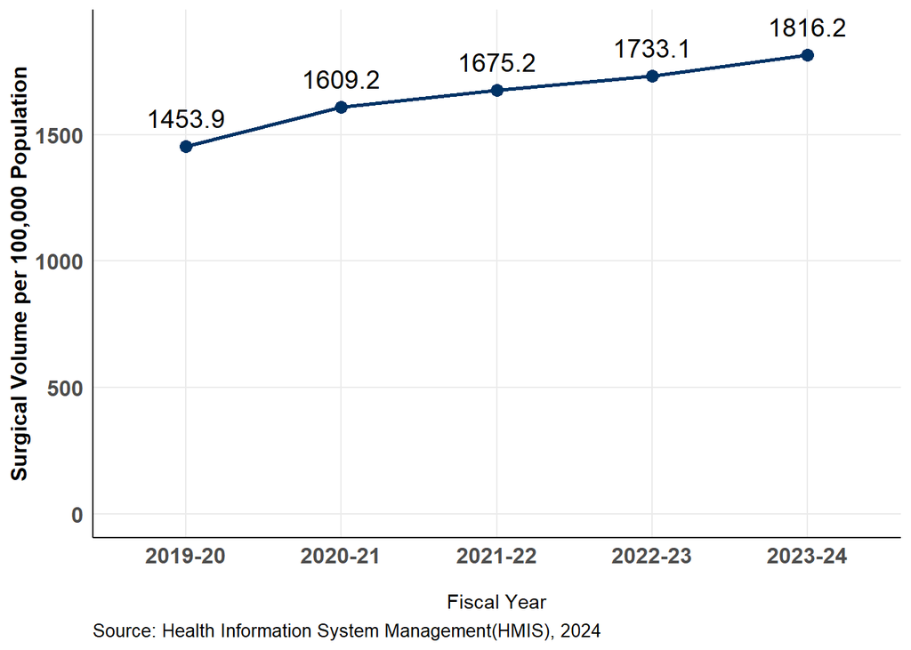

```r
data <- data.frame(
  Period = c("2019-20", "2020-21", "2021-22", "2022-23", "2023-24"),
  Values = c(1453.9, 1609.2, 1675.2, 1733.1, 1816.2)
)

# Line plot
p <- ggplot(data, aes(x = Period, y = Values, group = 1)) +
  geom_line(color = "#003366", size = 1) +       # Line settings
  geom_point(size = 3, color = "#003366") +      # Points on the line
  geom_text(
    aes(label = Values),
    vjust = -1,
    size = 5,
    color = "black",
    family = "sans"
  ) +scale_y_continuous(
    limits = c(0, 1900))+
  labs(
    x = "\nFiscal Year",
    y = "Surgical Volume per 100,000 Population",
    caption = "Source: Health Information System Management(HMIS), 2024"
  ) +
  theme_minimal() +
  theme(
    text = element_text(family = "sans"),
    axis.title.y = element_text(size = 12, face = "bold"),
    axis.title.X = element_text(size = 12, face = "bold"),
    axis.text = element_text(size = 12, face = "bold"),
    panel.grid.minor = element_blank(),
    axis.line = element_line(color = "black", size = 0.4),
    plot.caption = element_text(size = 10, hjust = 0)
  )



print(p)
```

Figure : Average time VS target time indicators in 2023/24

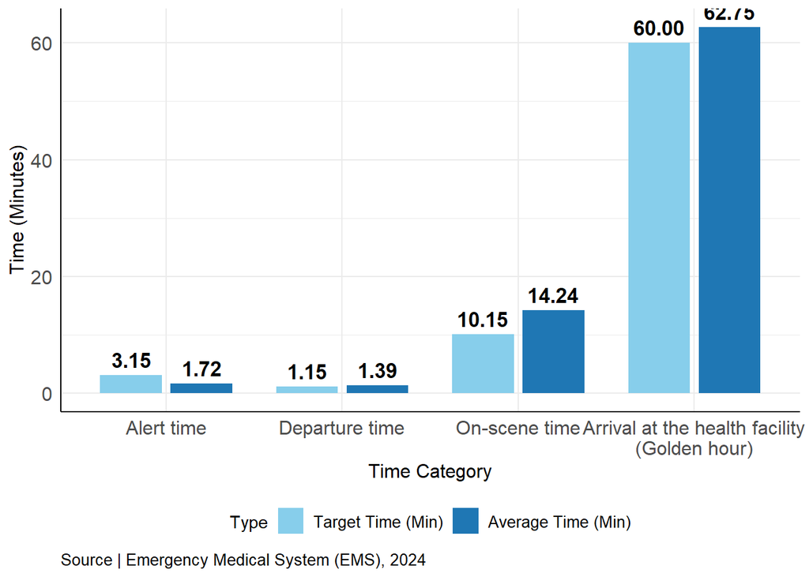

```r
# Load required libraries
library(ggplot2)
library(dplyr)

# Data
categories <- c(
  "Alert time",
  "Departure time",
  "On-scene time",
  "Arrival at the health facility\n(Golden hour)"
)
target_times <- c(3.15, 1.15, 10.15, 60)
average_times <- c(1.72, 1.39, 14.24, 62.75)

# Combine data into a data frame
data <- data.frame(
  Category = rep(categories, 2),
  Time = c(target_times, average_times),
  Type = rep(c("Target Time (Min)", "Average Time (Min)"), each = length(categories))
)

# Rearrange 'Type' factor levels to ensure the order of bars
data$Type <- factor(data$Type, levels = c("Target Time (Min)", "Average Time (Min)"))

# Rearrange 'Category' factor levels to ensure the specified order
data$Category <- factor(data$Category, levels = categories)

# Define colors
target_color <- "#87ceeb"  # Dark blue
average_color <- "#1f77b4"  # Sky blue

# Plot
ggplot(data, aes(x = Category, y = Time, fill = Type)) +
  geom_bar(stat = "identity", position = position_dodge(width = 0.8), width = 0.7) +
  geom_text(aes(label = sprintf("%.2f", Time)),
            position = position_dodge(width = 0.8),
            vjust = -0.5,
            size = 4.5,
            color = "black",
            fontface = "bold") +
  scale_fill_manual(values = c("Target Time (Min)" = target_color,
                               "Average Time (Min)" = average_color)) +
  labs(
    x = "Time Category",
    y = "Time (Minutes)",
    caption = "Source | Emergency Medical System (EMS), 2024"
  ) +
  theme_minimal(base_family = "sans") +
  theme(
    axis.text.x = element_text(size = 12),
    axis.text.y = element_text(size = 12),
    axis.title = element_text(size = 12),
    axis.line = element_line(color = "black", size = 0.4),
    legend.position = "bottom",
    legend.text = element_text(size = 10),
    plot.caption = element_text(size = 10, hjust = 0)
  )
```

Figure 30: PBF allocated to the facilities and community program, 2023/24

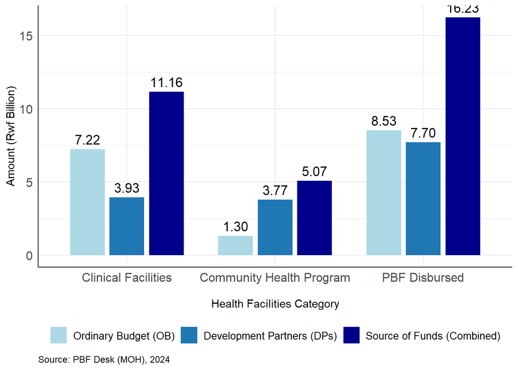

```r
data <- data.frame(
  Category = c("Clinical Facilities",
               "Community Health Program",
               "PBF Disbursed"),
  OB = c(7.22, 1.30, 8.53),
  DPs = c(3.93, 3.77, 7.70),
  Combined = c(11.16, 5.07, 16.23)
)
data_melted <- melt(data, id.vars = "Category",
                    variable.name = "Source_of_Fund",
                    value.name = "Amount")

# Define custom colors for the funding sources
source_colors <- c(
  "OB" = "lightblue",       # Dark blue
  "DPs" = "#1f77b4",      # Orange
  "Combined" = "#00008B" # Green
)

# Plot
plot <- ggplot(data_melted, aes(x = Category, y = Amount, fill = Source_of_Fund)) +
  geom_bar(stat = "identity", position = position_dodge(width = 0.8), width = 0.7) +  # Adjust dodge and bar width
  geom_text(aes(label = sprintf("%.2f", Amount)),
            position = position_dodge(width = 0.8),
            vjust = -0.5,
            size = 4.5,
            color = "black") +
  scale_fill_manual(values = source_colors, labels = c(
    "OB" = "Ordinary Budget (OB)",
    "DPs" = "Development Partners (DPs)",
    "Combined" = "Source of Funds (Combined)"
  )) +
  labs(
    x = "\nHealth Facilities Category",
    y = "Amount (Rwf Billion)",
    fill = "Source of Fund",
    caption = "Source: PBF Desk (MOH), 2024"
  ) +
  theme_minimal(base_family = "sans") +
  theme(axis.line = element_line(color = "black", size = 0.4),
        plot.caption = element_text(family = "sans", size = 9, hjust = 0),
    axis.text.x = element_text(size = 12),  # Increase x-axis label size
    axis.text.y = element_text(size = 12),  # Increase y-axis label size
    axis.title = element_text(size = 11),  # Increase axis title size
    legend.position = "bottom",            # Place legend at the bottom
    legend.title = element_blank(),        # Remove legend title
    legend.text = element_text(size = 10),  # Adjust legend text size
  )

print(plot)
```